# TFM - Classification of semi-structured answers in audio

##### Global PCA (Pooled PCA across all index dimensions)

As there are so many indexes, models, prompts and metrics, it seems complicated to compare the results. Therefore, I added a PCA analysis to the table:

```r
pca_data <- results_all %>%
  mutate(OneOffAcc = OneOffAcc / 100) %>%
  select(MAE, Spearman, OneOffAcc) %>%
  scale()
pca_result <- prcomp(pca_data, center = TRUE, scale. = TRUE)
summary(pca_result)
```

```
## Importance of components:
##                           PC1    PC2     PC3
## Standard deviation     1.5441 0.7448 0.24682
## Proportion of Variance 0.7948 0.1849 0.02031
## Cumulative Proportion  0.7948 0.9797 1.00000
```

```r
pca_result$rotation
```

```
##                  PC1        PC2       PC3
## MAE       -0.6290993 -0.1988702 0.7514551
## Spearman   0.5041221 -0.8402330 0.1996733
## OneOffAcc  0.5916883  0.5044394 0.6288449
```

`pca_result$rotation` shows that this time PC1 is defined in the same direction of the metrics (lower MAE, higher Spearman and OneOffAcc means higher PCA), so, there is no need to change the signal of PC1 here.

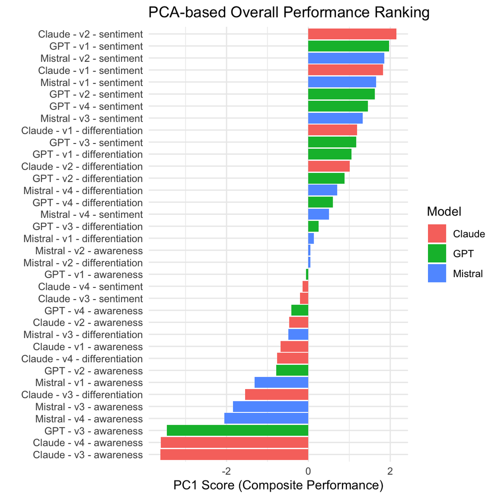

```r
results_pca <- results_all %>%
  mutate(PC1 = pca_result$x[, 1]) %>%
  arrange(desc(PC1))
p <- results_pca %>%
  mutate(label = paste(Model, PromptVersion, Index, sep = " - ")) %>%
  ggplot(aes(x = reorder(label, PC1), y = PC1, fill = Model)) +
  geom_col() +
  coord_flip() +
  labs(
    title = "PCA-based Overall Performance Ranking",
    x = "",
    y = "PC1 Score (Composite Performance)"
  ) +
  theme_minimal(base_size = 11)
p
```

```r
save_my_plot(p, "figure9_results_pca.png")
```

It is important to notice in the plot above that, although the same prompt-model pair appears multiple times in the chart (e.g., GPT-v2), each entry represents a different evaluation index (awareness, sentiment, or differentiation), with its own set of metrics. Therefore, PCA was applied globally across all 36 prompt-model-index combinations, and it is fair to compare the performance for all indexes in one table.